# HW 3

Musie Gebreegziabher

11/27/2023

# 1

In this homework, we will discuss support vector machines and tree-based methods. I will begin by simulating some data for you to use with SVM.

```r
library(e1071)
```

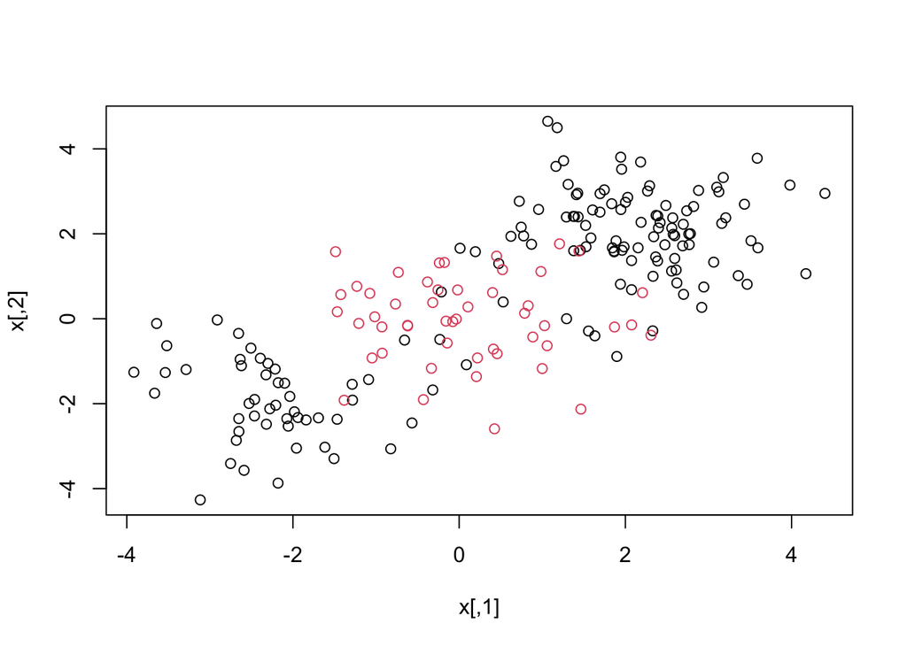

```r
set.seed(1)
x=matrix(rnorm(200*2),ncol=2)
x[1:100,]=x[1:100,]+2
x[101:150,]=x[101:150,]-2
y=c(rep(1,150),rep(2,50))
dat=data.frame(x=x,y=as.factor(y))
plot(x, col=y)
```

## 1.1

Quite clearly, the above data is not linearly separable. Create a training-testing partition with 100 random observations in the training partition. Fit an svm on this training data using the radial kernel, and tuning parameters $\gamma=1$, cost $=1$. Plot the svm on the training data.

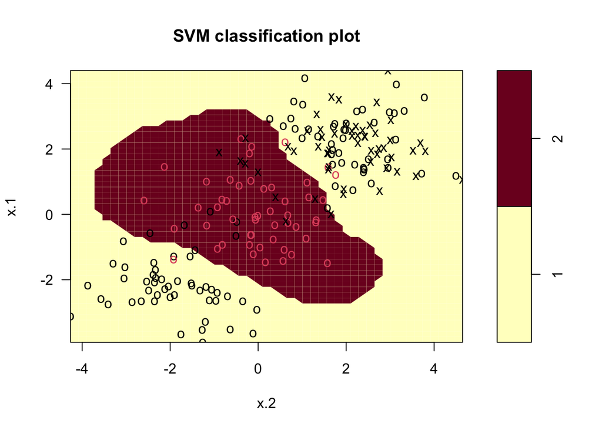

```r
set.seed(101)
train<- sample(1:150, 100)


svmfit = svm(y ~ ., data = dat[-train, ], kernel = "radial", cost = 1, gamma = 1, scale = FALSE)
plot(svmfit, dat)
```

## 1.2

Notice that the above decision boundary is decidedly non-linear. It seems to perform reasonably well, but there are indeed some misclassifications. Let’s see if increasing the cost [^1] helps our classification error rate. Refit the svm with the radial kernel, $\gamma=1$, and a cost of 10000. Plot this svm on the training data.

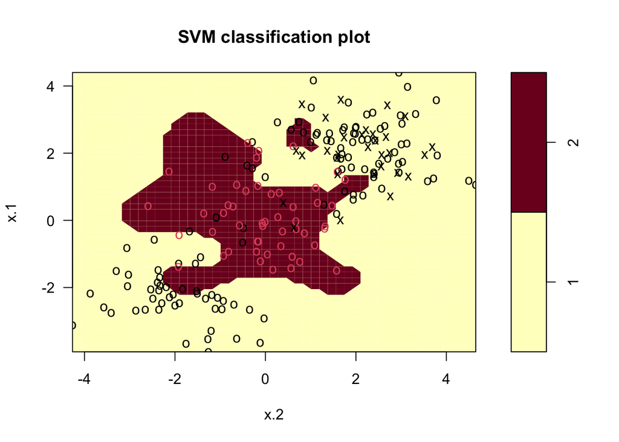

```r
svmfit = svm(y ~ ., data = dat[-train,], kernel = "radial", cost = 10000, gamma = 1, scale = FALSE)
plot(svmfit, dat)
```

## 1.3

It would appear that we are better capturing the training data, but comment on the dangers (if any exist), of such a model.

*The dangers of such a model with very high costs is overfitting, allowing the model to fit data very close to each other which can make the model not catch actual data.*

## 1.4

Create a confusion matrix by using this svm to predict on the current testing partition. Comment on the confusion matrix. Is there any disparity in our classification results?

```r
ConfusionMatrix <- table(true=dat[-train,"y"], pred=predict(svmfit, newdata=dat[-train,]))
ConfusionMatrix
```

```
##     pred
## true  1  2
##    1 50  0
##    2  1 49
```

## 1.5

Is this disparity because of imbalance in the training/testing partition? Find the proportion of class `2` in your training partition and see if it is broadly representative of the underlying 25% of class 2 in the data as a whole.

## 1.6

Let’s try and balance the above to solutions via cross-validation. Using the `tune` function, pass in the training data, and a list of the following cost and $\gamma$ values: {0.1, 1, 10, 100, 1000} and {0.5, 1,2,3,4}. Save the output of this function in a variable called `tune.out`.

```r
set.seed(1)
cost <- c(0.1, 1, 10, 100, 1000)
gamma <- c(0.5, 1, 2, 3, 4)

tune.out <- tune(svm, y ~ ., data = dat[-train, ], kernel = "radial", ranges = list(cost = cost, gamma = gamma))
```

I will take `tune.out` and use the best model according to error rate to test on our data. I will report a confusion matrix corresponding to the 100 predictions.

```r
table(true=dat[-train,"y"], pred=predict(tune.out$best.model, newdata=dat[-train,]))
```

```
##     pred
## true  1  2
##    1 46  4
##    2  4 46
```

## 1.7

Comment on the confusion matrix. How have we improved upon the model in question 2 and what qualifications are still necessary for this improved model.